# Flexible vocal timing adaptation to predictable and unpredictable playback noise

Ava Kiai

### About

In this experiment, we played amplitude modulated white noise to a group of bats in order to investigate their ability to temporally modulate their calling behavior at the group level.

We hypothesized that bats would adapt the timing of their calls to avoid temporal overlap with the amplitude modulated noise.

After extracting call timins from acoustic recordings (.wav files) and identifying the instantaneous period (or phase) in the real or simulated (as in the silent condition) amplitude modulation cycle, we analyzed the call onset data, primarily with circular statistics.

### Setup

```r
packages <- c("circular", "CircStats", "CircSpaceTime", "sjPlot", "yarrr", "janitor", "broom", "knitr",  "kableExtra", "car", "MASS", "emmeans", "rcompanion", "pscl", "randomForest", "chisq.posthoc.test", "viridis", "scales","ggh4x","ggside", "ggdist", "ggridges","gganimate","plotly","htmlwidgets","scatterplot3d","tidyverse")

# Install packages not yet installed
installed_packages <- packages %in% rownames(installed.packages())
if (any(installed_packages == FALSE)) {
  install.packages(packages[!installed_packages])
}

# Packages loading
invisible(lapply(packages, library, character.only = TRUE))
```

### Parameters

```r
str(params)
```

```
## List of 7
##  $ subsample   : logi FALSE
##  $ data_path   : chr "./../1-data"
##  $ results_path: chr "./../3-results"
##  $ exp         : chr "exp_1"
##  $ plot_sm     : logi TRUE
##  $ use_all     : logi TRUE
##  $ seed        : num 42
```

```r
# local paths
data_path <- params$data_path
results_path <- params$results_path
tables_path <- file.path(results_path,'tables')
  if (!dir.exists(tables_path)) dir.create(tables_path)
figures_path <- file.path(results_path,'figures')
  if (!dir.exists(figures_path)) dir.create(figures_path)
models_path <- file.path(results_path,'models')
  if (!dir.exists(models_path)) dir.create(models_path)
sm_path <- file.path(results_path,'supplementary_figures')
  if (!dir.exists(sm_path)) dir.create(sm_path)

# experiment number
exp <- params$exp

# seed for subsampling
seed <- params$seed

# whether to use all data for circular stats
use_all <- params$use_all
subsample <- params$subsample

# whether to plot supplementary plots/tables
supplementary <- params$plot_sm
```

#### Load data

```r
# load data
data <- readr::read_rds(file.path(data_path,'input',paste0(exp, "_data.RDS"))) %>%
  mutate(start_phase_circ = circular(start_phase, units="radians", zero = 0, modulo = "2pi", rotation = "counter"),.after ="start_phase")

# data for averaging histograms (modulation variable is numeric-ish)
data_2proc <- data %>%
  mutate(modulation = factor(modulation,
                             levels = sort(unique(data$modulation))))

# data for remaining analyses (modulation variable is character-ish, better for plotting)
data <- data %>%
  mutate(modulation = factor(modulation,
                             levels = sort(unique(data$modulation)),
                             labels = paste0(as.character(sort(unique(data$modulation))),"Hz")))
str(data)
```

```
## 'data.frame':    1425067 obs. of  23 variables:
##  $ group           : Factor w/ 4 levels "1","2","3","4": 1 1 1 1 1 1 1 1 1 1 ...
##  $ session         : int  1 1 1 1 1 1 1 1 1 1 ...
##  $ part            : int  1 1 1 1 1 1 1 1 1 1 ...
##  $ condition       : Factor w/ 3 levels "silence","full-band masker",..: 1 1 1 1 1 1 1 1 1 1 ...
##  $ modulation      : Factor w/ 2 levels "8Hz","15Hz": 2 2 2 2 2 2 2 2 2 2 ...
##  $ minute          : num  1 1 1 1 1 1 1 1 1 1 ...
##  $ start_seconds   : num  0.0464 0.1238 0.1741 0.2302 0.2951 ...
##  $ stop_seconds    : num  0.0498 0.1278 0.1776 0.2359 0.3031 ...
##  $ start_sp        : num  11607 30946 43515 57559 73768 ...
##  $ end_sp          : num  12460 31947 44409 58980 75776 ...
##  $ start_cycle     : int  1 2 3 4 5 6 7 8 8 9 ...
##  $ end_cycle       : int  1 2 3 4 5 6 7 8 8 9 ...
##  $ start_phase     : num  4.37 5.38 3.83 2.84 2.66 ...
##  $ start_phase_circ: 'circular' num  4.37 5.38 3.83 2.84 2.66 ...
```

[output cut: 16 more lines]

```r
# save interim data manips to 1-data/output
data_path <- file.path(data_path,'output')
  if (!dir.exists(data_path)) dir.create(data_path)
```

### Summary Stats

A few rough summary statistics. Note that each row is an observation (call event), with parameters:

- group: experimental group (1:4) (Note that for experiment 1, there were 8 groups of bats tested in each modulation rate context, but each is labelled 1-4.)
- session: recording day (1:5)
- part: experimental block (1:3), silent condition is always part 1
- condition: playback condition
- modulation: amplitude modulation rate for masking conditions
- minute: minute since the start of the recording file in which the call occurred
- start_seconds: timestamps of call onsets in seconds since the start of the file
- stop_seconds: ibid. for call offsets
- start_sp: samples since start of file at call onset
- end_sp: ibid. for call offsets
- start_cycle: nth cycle of the corresponding modulation rate in the corresponding file at call onset
- end_cycle: ibid. at call onset
- start_phase: moment in the corresponding modulation cycle (in radians) at call onset
- start_phase_circ: ibid., but of class circular
- end_phase: ibid. at call offset
- start_per: timepoint in the corresponding modulation period (in seconds) at call onset
- end_per: ibid. at call offset
- duration: call offset - call onset (in seconds)
- onset_interval: call onset - previous call’s call onset (is NA if call is the first in the file)
- class: type of call (for now, all are labelled “call”)
- file_no: index of recording file, indicating the order of recorded files from the corresponding experimental block
- familiarization: number of days in which bats were housed together as a group prior to the first recording day
- order: randomization/counter-balancing order for the presentation of masking conditions

```r
#summary(data)
```

Total number of calls:

```r
nrow(data)
```

```
## [1] 1425067
```

```r
#1,425,067 # exp 1
#1,088,994 # exp 2
# = 2,514,061 # total
```

Call durations:

```r
# durations
# data1 <- data
# data2 <- data
# data <- rbind(data1,data2)
# nrow(data)

summary(data$duration)
```

```
##     Min.  1st Qu.   Median     Mean  3rd Qu.     Max.
## 0.000996 0.001692 0.003556 0.004526 0.005544 0.247540
```

```r
# #    Min.  1st Qu.   Median     Mean  3rd Qu.     Max.
# #0.000996 0.001704 0.003372 0.004246 0.005036 0.704744

IQR(data$duration)
```

```
## [1] 0.003852
```

```r
# # 0.003332
```

### Distribution of call onsets in the modulation cycle

Calculate histogram averages (essentially, a PSTH)

```r
call_summary1 <- get_avg_hist(data_2proc, NULL, list("group","session"), "period",
                              by_group = TRUE, by_session = TRUE)
call_summary60 <- get_avg_hist(data_2proc, 60, list("group","session"), "period")

# optionally: check that the two have the correct # of bins
# call_summary1$generic %>% group_by(modulation) %>% summarise(sort(unique(mids),decreasing = T)[2])
# call_summary60$generic %>% group_by(modulation) %>% summarise(n=length(unique(mids)))
```

First, we asked: Did the presence of playback noise affect the distribution of emitted calls within the modulation cycle?

Here we plot an averaged histogram of detected call onsets (binned calls (1 ms bins) summed over all cycles, averaged over groups and recording days):

Points are mean # calls, shaded areas are +- sem…

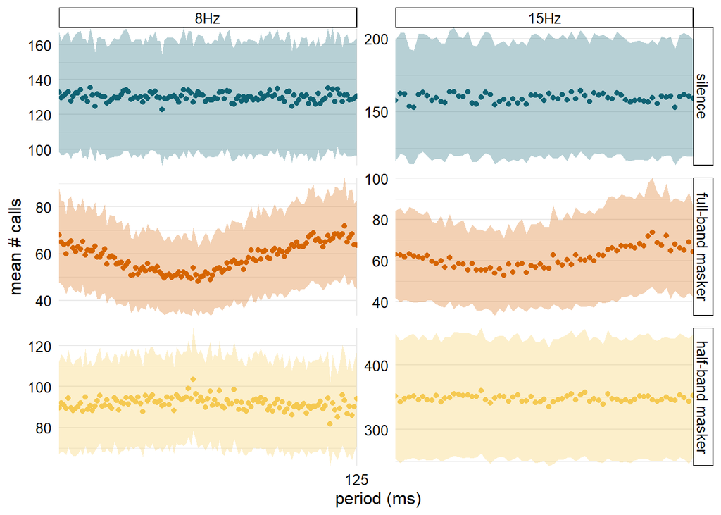

```r
# average call counts all at once, 1 ms bins
p <- p.hist_avg_dot_kwargs(dat = call_summary1$generic, facets = c("condition","modulation"))
 print(p)
```

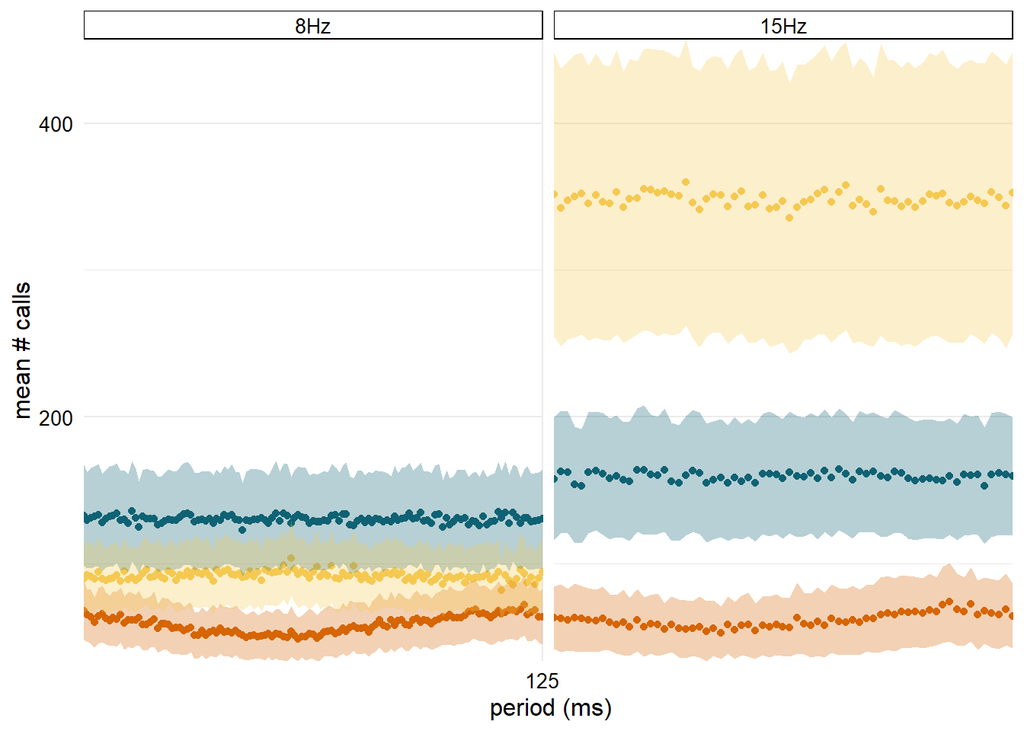

```r
 ggsave(file.path(figures_path,paste0(exp, '_fig1a.png') ), p, width = w, height = 5)

# average call counts with fixed y-axis, to better illustrate the relative calling rate between conditions
p2 <- p.hist_avg_dot_kwargs_fixedy(dat = call_summary1$generic, facets = c("","modulation"))
  print(p2)
```

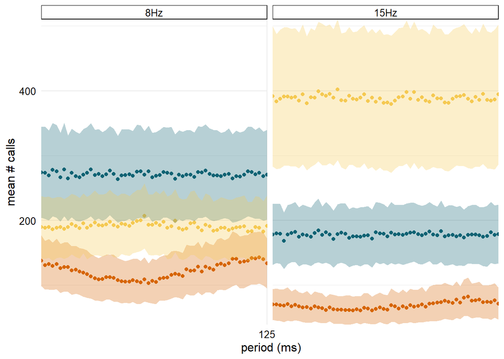

```r
 ggsave(file.path(figures_path,paste0(exp, '_fig1a-alt1.png') ), p2, width = w, height = 5)

# average call counts with fixed y-axis, with 60 ms bins for each modulation rate, to show trend on the same x-scale across conditions
p3 <- p.hist_avg_dot_kwargs_fixedy(dat = call_summary60$generic, facets = c("","modulation"))
  print(p3)
```

```r
  ggsave(file.path(figures_path,paste0(exp, '_fig1a-alt2.png') ), p3, width = w, height = 5)
```

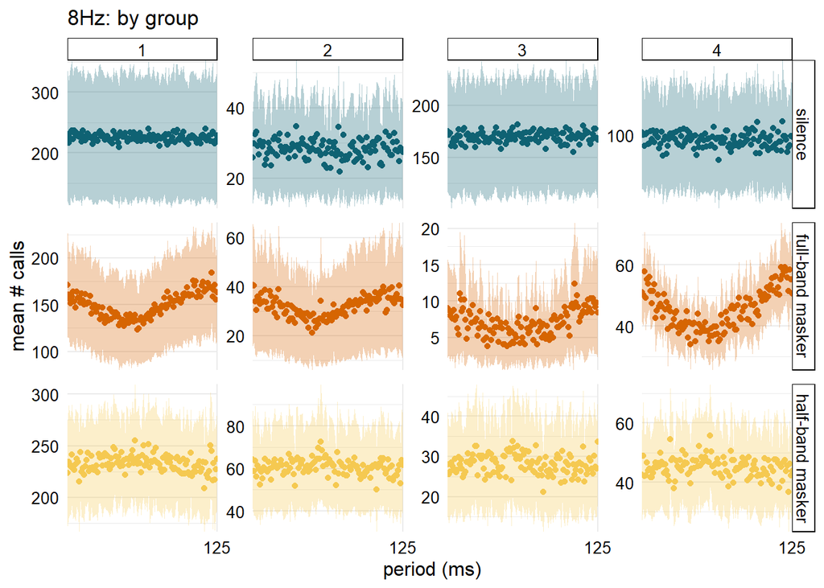

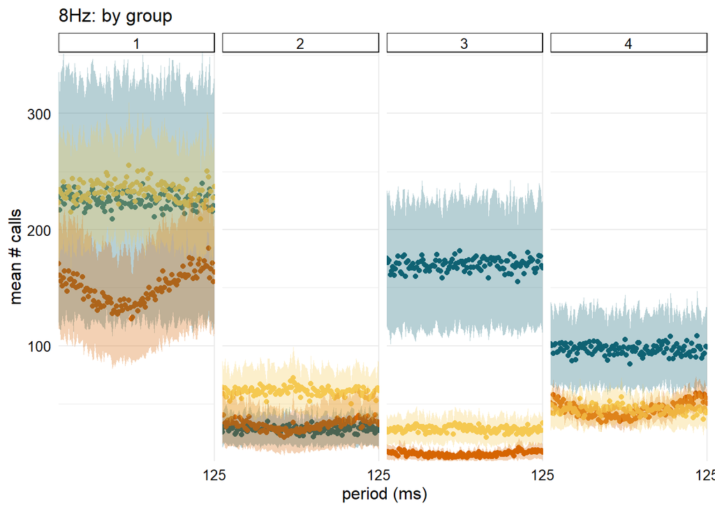

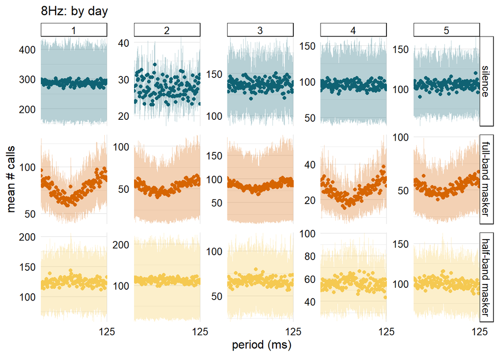

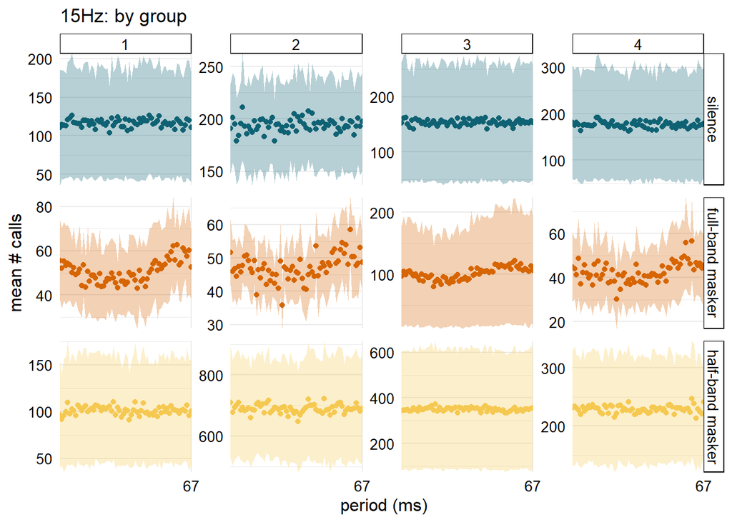

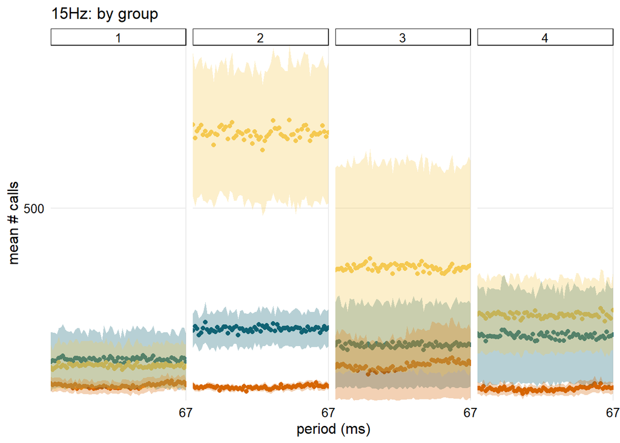

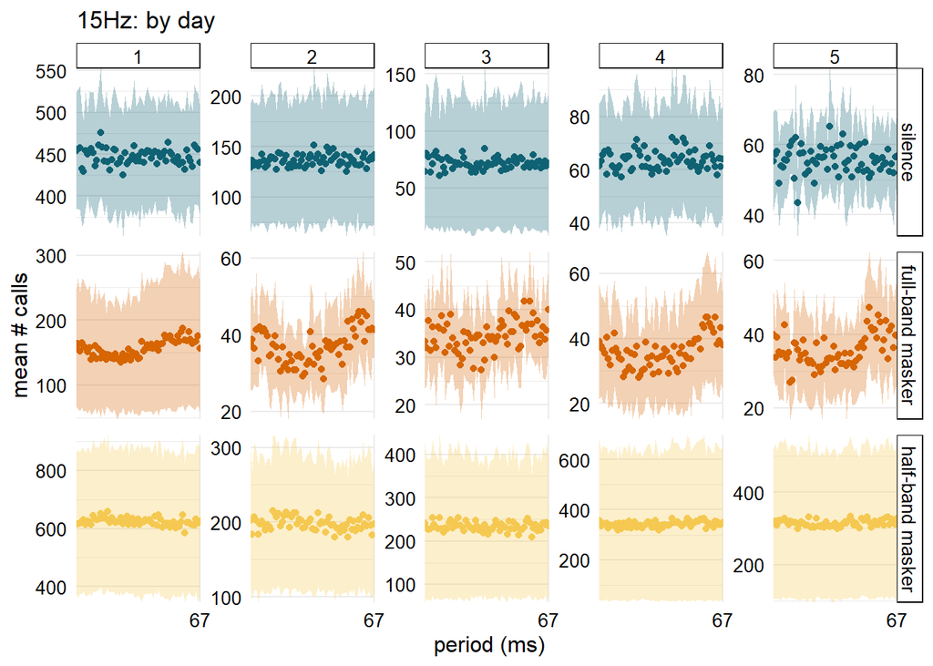

```r
# show average call counts (with and without fixed y axis) for each group, and for each recording day ("session")
for (m in sort(unique(call_summary1$group$modulation))) {
 p1 <- p.hist_avg_dot_kwargs(dat = call_summary1$group %>% filter(modulation == m),
                             facets = c("condition","group")) +
                             ggtitle(paste0(m, ": by group"))
 p2 <- p.hist_avg_dot_kwargs_fixedy(dat = call_summary1$group %>% filter(modulation == m),
                                    facets = c("","group")) +
                             ggtitle(paste0(m, ": by group"))
 p3 <- p.hist_avg_dot_kwargs(dat = call_summary1$session %>% filter(modulation == m),
                             facets = c("condition","session")) +
                             ggtitle(paste0(m, ": by day"))

 print(p1); print(p2); print(p3)
 ggsave(file.path(sm_path,paste0(exp, '_figs3a_',m,'.png') ),
        p1, width = 7, height = 5)
 ggsave(file.path(sm_path,paste0(exp, '_figs3a_',m,'-alt1.png') ),
        p2, width = 7, height = 5)
 ggsave(file.path(sm_path,paste0(exp, '_figs3b_',m,'.png') ),
        p3, width = 7, height = 5)
}
```

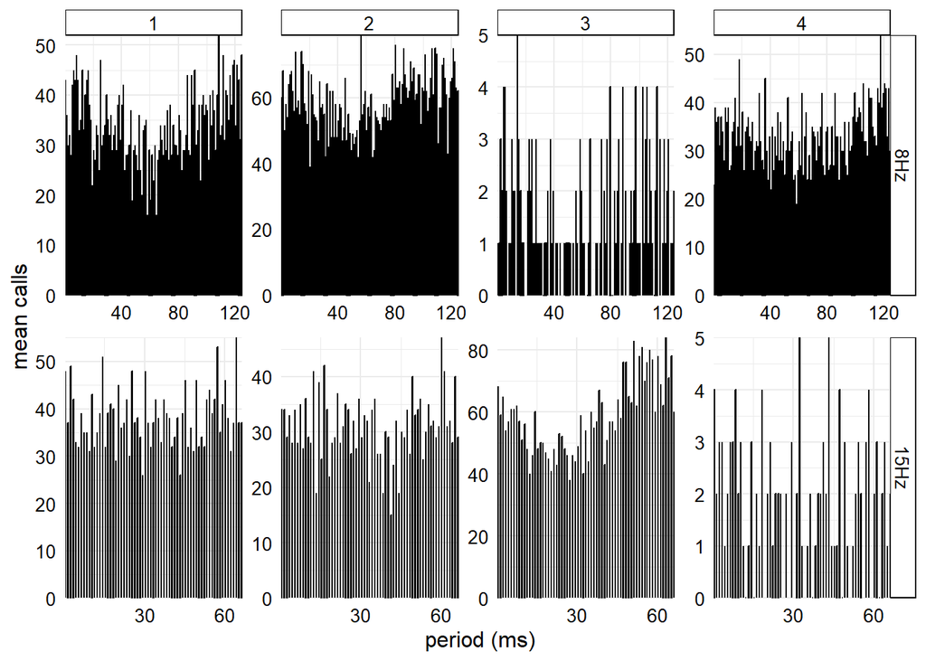

```r
# show average hist of binned calls for the first 7.5-8 mins of continuous AM playback for each mod.
call_summary1_init <- get_avg_hist(data_init, NULL, list("group"), "period", by_group = TRUE)
#str(data_init)

firsts <- p.hist_avg_col(dat = call_summary1_init$group %>%
                 dplyr::filter(condition=="full-band masker" | condition=="steady-state masker"),
               facets = c("modulation","group"))

print(firsts)
```

```r
ggsave(file.path(sm_path,paste0(exp, '_figs4.png') ), firsts, width = 7, height = h2)
```

### Circular Statistics

To analyze the distribution of call onsets within the modulation cycle, we must use circular statistics (with functions from the package `circular`), since the nature of our data is cyclical.

First we will compute the following summary statistics:

- Mean Resultant Direction ($\bar{\theta}$)
- Mean Resultant Length ($\bar{R}$)
- Circular Variance ($Vm$): $1-R$
- Circular Standard Deviation ($v$): $\sqrt{1-2*log(\bar{R})}$
- MLE Mu ($\mu$): mean parameter estimated from the maximum likelihood von Mises distribution (`circular::mle.vonmises()`)
- MLE Kappa ($\kappa$): concentration parameter estimated from the maximum likelihood von Mises distribution (`circular::mle.vonmises()`)
- MLE CIs for $\bar{\theta}$: confidence intervals for the mean parameters estimated from the maximum likelihood von Mises distribution (`circular::mle.vonmises.bootstrap.ci()`)

Then, we’ll get bootsrapped mean and concentration parameters from the whole dataset.

We predicted that calls emitted in presence of modulated noise would tend to “cluster” unimodally in the hemisphere corresponding to the amplitude trough. Conversely, we predicted that the distribution of call onsets emitted in silence would show no clustering, and therefore resemble a uniform distribution.

This prediction entails two specific hypotheses:

1. Distribution of calls detected in silence will be equivalent to a uniform distribution, while that of calls detected in the presence of masking noise will deviate from the uniform distribution. –> Method: Rayleigh test of uniformity (`circular::rayleigh.test(x, mu=circular(0))`)
2. The distribution of calls in the playback conditions will each besignificantly different from the silence condition. –> Method: Mardia-Watson-Wheeler non-parametric test of homogeneous samples (`circular::watson.wheeler.test(x,y)`), where differences between samples can be in either the mean or the variance.

#### Calculate summary and distribution statistics

**In which conditions were call onset distributions unimodally clustered?**

```r
# prepare data for analysis: split into lists, one for each modulation x condition case
# data is subsampled if requested in header

data_split <-  data_samp %>% group_by(modulation, condition) %>% group_split()

# label and convert to circular data
circ_data <- lapply(data_split, function(x)
  list(modulation = unique(x$modulation),
       condition = unique(x$condition),
       phase = x$start_phase_circ))


if (file.exists(f_circsum)) { # as RDS...
  circ_summary <- readr::read_rds(f_circsum)

} else {
  # calculate values:
  circ_datsum <- lapply(circ_data,
         function(x) tibble(modulation = x$modulation,
                            condition = x$condition,
                            n = length(x$phase),
                            theta_bar = mean.circular(x$phase, na.rm = T), # angular mean
                            r_bar = rho.circular(x$phase, na.rm = T), # mean resultant length
                            vm = var.circular(x$phase),
                            v = sd.circular(x$phase),
                            # Test of uniformity:
                            rt = rayleigh.test(x$phase, mu=circular(0))$statistic,
                            p = rayleigh.test(x$phase, mu=circular(0))$p.value,
                            # MLE von Mises:
                            mle_mu = mle.vonmises(x$phase)$mu,
                            bs_mu_ci_l = mle.vonmises.bootstrap.ci(x$phase, alpha=.05)$mu.ci[1],
                            bs_mu_ci_h = mle.vonmises.bootstrap.ci(x$phase, alpha=.05)$mu.ci[2],
                            mle_kappa = mle.vonmises(x$phase)$kappa)
                        )

  # wrangle & correct p values
  circ_summary <- tibble(do.call(rbind,circ_datsum))  %>%
                  mutate(p_adjust = p.adjust(p, method ="bonferroni"), .after = "p") %>%
                  mutate(across(where(is.numeric), round, 3))

  head(circ_summary)

  # save, if first time
  if (subsample) {
    write.csv(circ_summary, file = file.path(data_path,paste0(exp, "_circ_data_seed",seed,".csv")), row.names = F)
    readr::write_rds(circ_summary, file = file.path(data_path,paste0(exp, "_circ_data_seed",seed,".RDS")))
  } else {
    write.csv(circ_summary, file = file.path(data_path,paste0(exp, "_circ_data-alldata.csv")), row.names = F)
    readr::write_rds(circ_summary, file = file.path(data_path,paste0(exp, "_circ_data-alldata.RDS")))
  }

}

circ_summary
```

```
## # A tibble: 6 × 14
##   modulation condition             n theta_bar  r_bar    vm     v     rt     p p_adjust mle_mu     bs_mu_ci_l bs_mu_c…¹ mle_k…²
##   <fct>      <fct>             <dbl> <circular> <dbl> <dbl> <dbl>  <dbl> <dbl>    <dbl> <circular> <circular> <circula>   <dbl>
## 1 8Hz        silence          325333 0.738      0.001 0.999  3.72  0.001 0.279        1 0.738      4.076      4.135       0.002
## 2 8Hz        full-band masker 146187 5.752      0.067 0.933  2.32  0.058 0            0 5.752      5.696      5.807       0.135
## 3 8Hz        half-band masker 229311 2.579      0.011 0.989  2.99 -0.01  1            1 2.579      2.332      2.840       0.023
## 4 15Hz       silence          202822 3.933      0.001 0.999  3.66 -0.001 0.709        1 3.933      1.586      0.530       0.002
## 5 15Hz       full-band masker  78197 5.403      0.051 0.949  2.44  0.032 0            0 5.403      5.311      5.501       0.102
## 6 15Hz       half-band masker 443217 1.042      0.002 0.998  3.52  0.001 0.17         1 1.042      6.049      2.550       0.004
## # … with abbreviated variable names ¹bs_mu_ci_h, ²mle_kappa
```

#### Plot circular call density

Now, let’s plot our call count data (as a density rather than raw call count) as before, but on the polar plane and indicate the mean direction and resultant length of the resultant vector.

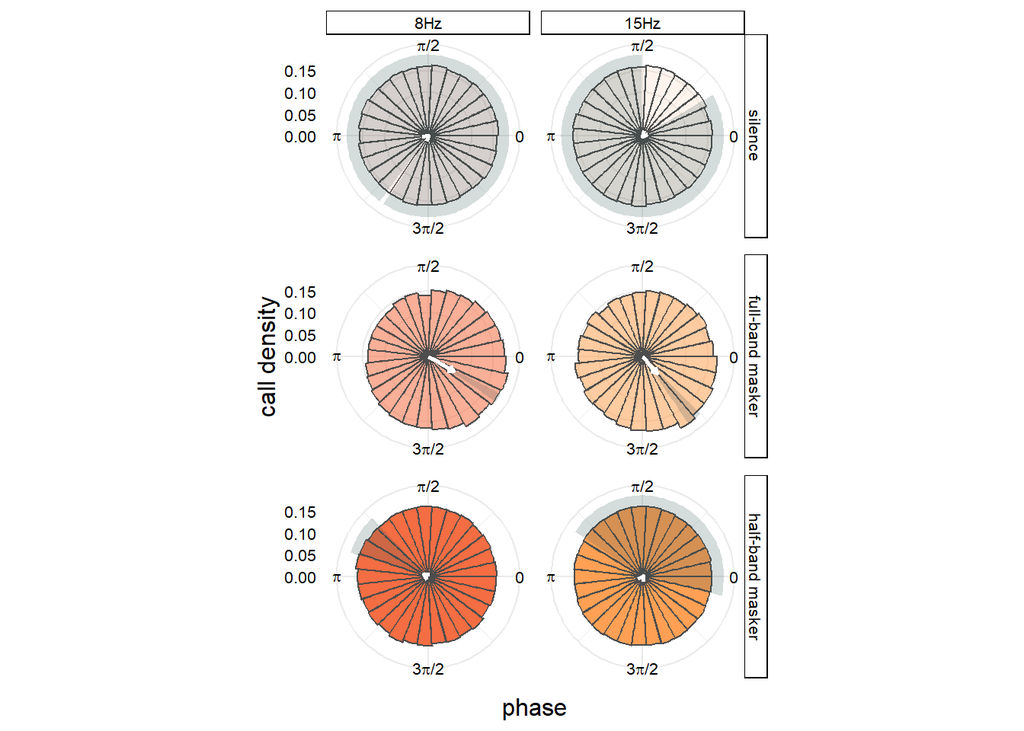

```r
circ_density <- p.circ_density(dat = data_samp, circ_dat = circ_summary_plot, bins = 30) %>% recolor(which="f")

circ_density
```

```r
if (subsample) {
  ggsave(file.path(figures_path,paste0(exp, "_fig1b_",seed,".png")), circ_density, width = w, height = 5)
} else {
  ggsave(file.path(figures_path,paste0(exp, '_fig1b.png')), circ_density, width = w, height = 5)
}
```

#### Calculate bootstrapped angular vectors

**How consistent was the clustering, if present?**

#### Plot bs parameters in the polar plane

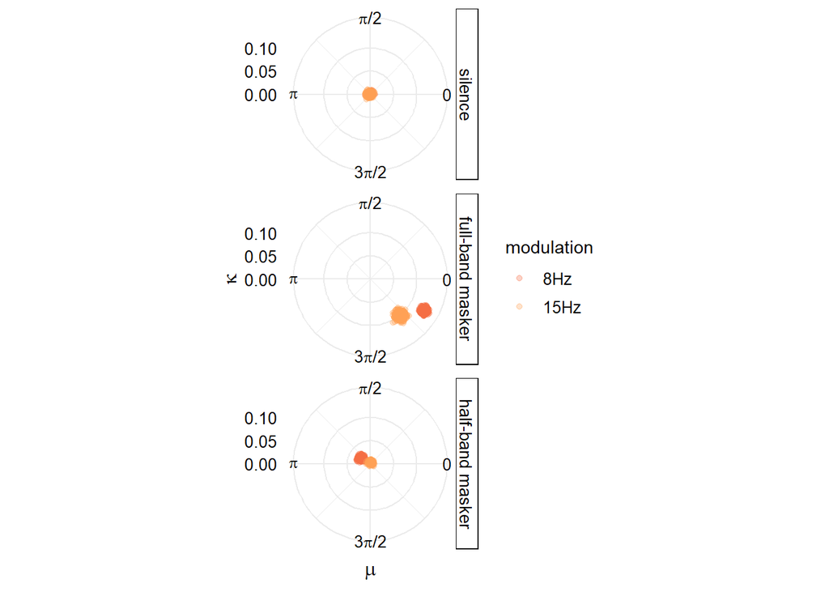

```r
circ_params <- p.circ_params(mu_bs_df, compress = T)  %>% recolor()


circ_params
```

```r
ggsave(file.path(figures_path,paste0(exp, '_fig1c.png')), circ_params, width = 3, height = 6)
```

##### … and in the cartesian plane

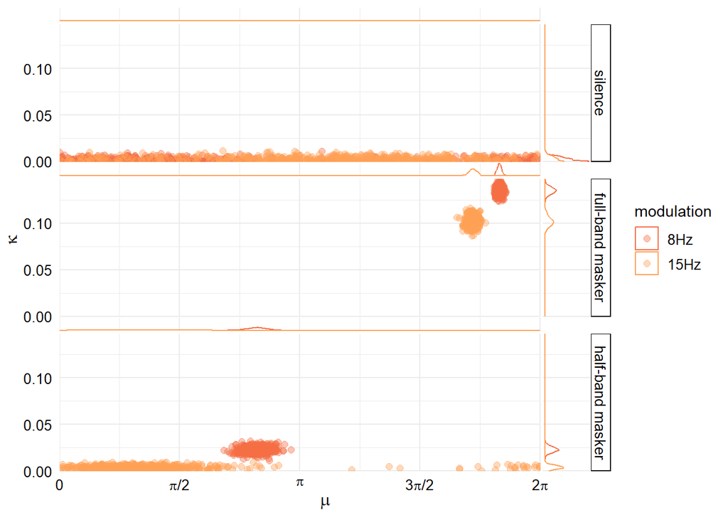

```r
mu_kappa <- p.mu_kappa(dat = mu_bs_df %>%
                         group_by(modulation, condition) %>%
                         slice_sample(n = 500)) %>% recolor()
mu_kappa
```

```r
ggsave(file.path(figures_path,paste0(exp, '_fig1d-500.png') ), mu_kappa, width = 6, height = 6)
```

#### [Mardia]-Watson-Wheeler Homogeneity of Samples

We now compute frequentist non-parametric analyses for whether the distributions of calls observed in our different modulation and masking conditions are identical.

The null hypothesis is that the distributions are identical, either in their means or their variances:

##### Compare playback conditions within modulation rate contexts

**Did distributions of call onsets differ between playback conditions at each modulation rate?**

```r
circ_data_df <- do.call(rbind, lapply(circ_data, function(x) as.data.frame(x)))

ww_tests <- lapply(sort(unique(circ_data_df$modulation)), function(x)
  watson.wheeler.test(phase ~ condition,circ_data_df[circ_data_df$modulation==x,]) %>%
    broom::tidy() %>%
     mutate(across(where(is.numeric), round, 3)) %>%
      mutate(modulation = x,.before=1)) %>%
  do.call(rbind,.) %>%
  mutate(p.adjust = p.adjust(p.value, method ="bonferroni"), .after = "p.value") %>%
  janitor::clean_names()

ww_tests
```

```
## # A tibble: 2 × 6
##   modulation statistic p_value p_adjust parameter method
##   <fct>          <dbl>   <dbl>    <dbl>     <dbl> <chr>
## 1 8Hz            1228.       0        0         4 Watson-Wheeler test for homogeneity of angles
## 2 15Hz            369.       0        0         4 Watson-Wheeler test for homogeneity of angles
```

#### Rao’s test of homogeneity of means, dispersions

Test if means or vector lengths were significantly different between conditions and, separately, across modulation rates:

#### Compare playback conditions within each modulation rate

**How did distributions of call onsets differ between playback conditions at each modulation rate?** **In their angular means or their polar concentrations?**

```r
rao_testsm <- do.call(rbind, lapply(sort(unique(circ_data_df$modulation)), function(x) {
    df <- circ_data_df[circ_data_df$modulation==x,] %>% group_split(condition)
    rao <- circular::rao.test(lapply(df,'[[', 'phase'))
    data.frame(modulation = as.factor(x),
               test = as.factor(c("polar vectors", "dispersions")),
               statistic = rao$statistic, df = rao$df, p_value = rao$p.value) %>%
      mutate(across(where(is.numeric), round, 3)) %>%
      mutate(p_adjust = p.adjust(p_value, method ="bonferroni"), .after = "p_value")
    }))

# test differences for playback conditions within mod rates
rao_testsm
```

```
##   modulation          test statistic df p_value p_adjust
## 1        8Hz polar vectors     0.477  2   0.788    1.000
## 2        8Hz   dispersions   346.680  2   0.000    0.000
## 3       15Hz polar vectors     2.708  2   0.258    0.516
## 4       15Hz   dispersions   100.345  2   0.000    0.000
```

```r
rao_testsc <- do.call(rbind, lapply(sort(unique(circ_data_df$condition)), function(x) {
    df <- circ_data_df[circ_data_df$condition==x,] %>% group_split(modulation)
    rao <- circular::rao.test(lapply(df,'[[', 'phase'))
    data.frame(condition = as.factor(x),
               test = as.factor(c("polar vectors", "dispersions")),
               statistic = rao$statistic, df = rao$df, p_value = rao$p.value) %>%
      mutate(across(where(is.numeric), round, 3)) %>%
      mutate(p_adjust = p.adjust(p_value, method ="bonferroni"), .after = "p_value")
    }))

# test differences for mod rates within conditions
rao_testsc
```

```
##          condition          test statistic df p_value p_adjust
## 1          silence polar vectors     0.001  1   0.977    1.000
## 2          silence   dispersions     0.014  1   0.905    1.000
## 3 full-band masker polar vectors    23.687  1   0.000    0.000
## 4 full-band masker   dispersions    29.478  1   0.000    0.000
## 5 half-band masker polar vectors     1.265  1   0.261    0.522
## 6 half-band masker   dispersions    13.930  1   0.000    0.000
```

#### Post-hoc

Next, let’s compute post-hoc comparisons for each significant test (by modulation rate) above by comparing each pair of masking conditions within each modulation condition for both rates, again using the Rao test.

```r
do_contrasts <- rao_testsm$modulation[rao_testsm$p_value<0.05]

circ_contrasts <- lapply(do_contrasts, function(x) {
  df <- circ_data_df[circ_data_df$modulation==x,]
  pairs <- t(combn(unique(df$condition), m=2))

  tests <- lapply(seq.int(nrow(pairs)), function(y) {
    condlist <- df[df$condition %in% pairs[y,],] %>% group_split(condition)
    rao <- circular::rao.test(condlist[[1]]$phase, condlist[[2]]$phase)
    data.frame(modulation = as.factor(x),
               condition = as.factor(paste(pairs[y,],collapse = " vs. ")),
               test = as.factor(c("polar vectors", "dispersions")),
               statistic = rao$statistic, df = rao$df, p_value = rao$p.value) %>%
      mutate(across(is.numeric, round, 3)) %>%
      mutate(p_adjust = p.adjust(p_value, method ="bonferroni"), .after = "p_value")
    }) %>% do.call(rbind,.)
  }
 )  %>% do.call(rbind,.)

circ_contrasts
```

```
##    modulation                             condition          test statistic df p_value p_adjust
## 1         8Hz          silence vs. full-band masker polar vectors     0.422  1   0.516     1.00
## 2         8Hz          silence vs. full-band masker   dispersions   332.013  1   0.000     0.00
## 3         8Hz          silence vs. half-band masker polar vectors     0.444  1   0.505     1.00
## 4         8Hz          silence vs. half-band masker   dispersions    14.766  1   0.000     0.00
## 5         8Hz full-band masker vs. half-band masker polar vectors     0.054  1   0.817     1.00
## 6         8Hz full-band masker vs. half-band masker   dispersions   307.346  1   0.000     0.00
## 7        15Hz          silence vs. full-band masker polar vectors     0.739  1   0.390     0.78
## 8        15Hz          silence vs. full-band masker   dispersions   100.231  1   0.000     0.00
## 9        15Hz          silence vs. half-band masker polar vectors     0.045  1   0.832     1.00
## 10       15Hz          silence vs. half-band masker   dispersions     0.193  1   0.660     1.00
## 11       15Hz full-band masker vs. half-band masker polar vectors     1.975  1   0.160     0.32
## 12       15Hz full-band masker vs. half-band masker   dispersions   100.029  1   0.000     0.00
```

### Rate of vocalizations

Let’s look at the overall number of calls observed in the three experimental conditions and within the two tested modulation rates.

#### Chi-square test for number of observed calls [not used in paper]

Two post-hoc hypotheses: 1. The number of calls observed in the silent condition would be be greater than that in the masking conditions. - Method: Pearson’s Chi-squared Test for Goodness-of-Fit - H1: Observed calls unevenly distributed across groups.

2. Fewer calls would be observed for the faster masking conditions compared with the slower masking conditions, due to the greater masking effect elicited by more rapid (i.e. “noisier”) amplitude modulations.
- Method: Pearson’s Chi-squared Test for Homogeneity
- H1: Two samples differ in their distribution between groups (levels of masking).

Contingency tables:

```r
n_calls <- data %>% group_by(modulation, condition) %>% summarise(n = n())

(n_conttable <- addmargins(table(data$modulation,data$condition), c(1,2)))
```

```
##
##        silence full-band masker half-band masker     Sum
##   8Hz   325333           146187           229311  700831
##   15Hz  202822            78197           443217  724236
##   Sum   528155           224384           672528 1425067
```

Goodness of fit tests (test of imbalanced observations) for conditions within each modulation rate:

```
##   8Hz :  X(2, N = 700831) = 68808.48, p < 0.01 (2-tailed)
##   15Hz :  X(2, N = 724236) = 285211.93, p < 0.01 (2-tailed)
```

Goodness of fit tests for rates within conditions:

```
##   silence :  X(1, N = 528155) = 28417.69, p < 0.01 (2-tailed)
##   full-band masker :  X(1, N = 224384) = 20601.47, p < 0.01 (2-tailed)
##   half-band masker :  X(1, N = 672528) = 68035.5, p < 0.01 (2-tailed)
```

In the chi-square results below, columns refer to the following data:

- `observed`: the observed counts,
- `expected`: the expected counts under the null hypothesis,
- `residuals`: the Pearson residuals, $(observed - expected) / \sqrt(expected)$,
- `stdres`: standardized residuals, $(observed - expected) / \sqrt(V)$,

where $V$ is the residual cell variance.

```
## Pearson's Chi-squared test for each modulation rate x condition:
```

```
##   Mods vs. Conds:  X(2, N = 1425067) = 116701.74, p < 0.01 (2-tailed)
```

```
## # A tibble: 6 × 9
##   condition        modulation observed  prop row_prop col_prop expected resid std_resid
##   <fct>            <fct>         <dbl> <dbl>    <dbl>    <dbl>    <dbl> <dbl>     <dbl>
## 1 silence          8Hz          325333 0.228    0.616    0.464  259740.  129.      228.
## 2 full-band masker 8Hz          146187 0.103    0.652    0.209  110349.  108.      165.
## 3 half-band masker 8Hz          229311 0.161    0.341    0.327  330741. -176.     -340.
## 4 silence          15Hz         202822 0.142    0.384    0.28   268415. -127.     -228.
## 5 full-band masker 15Hz          78197 0.055    0.348    0.108  114035. -106.     -165.
## 6 half-band masker 15Hz         443217 0.311    0.659    0.612  341787.  173.      340.
```

### Negative Binomial Regression

First we modelled our counts using a Poisson GLM. However, we observed that the data were highly overdispersed. For example, for the 8 Hz context, overdispersion was:

```r
# Poisson Regression
calls.glm <- glm(n ~  condition, family = poisson, data = n_calls_reg[n_calls_reg$modulation=="8Hz",])
# model summary
  # summary(calls.glm)

# check for overdispersion
OD.pr <- sum(residuals(calls.glm, type="pearson")^2)/df.residual(calls.glm)
print(OD.pr)
```

```
## [1] 16213.4
```

Therefore, we proceeded with a Negative Binomial GLM, which allows for overdispersion in the count variable.

We ran a model for each modulation rate separately, so that the reference group (Intercept) is meaningful for all model terms for our purposes, i.e. coefficient indicate changes in calling rate between silent baseline and each masking condition.

Our models are given by:
$$ln(\widehat{calls_{i}}) = Intercept +
\beta_1 Mask(condition_j = 2) + \beta_3 Mask(condition_j =
3)$$

Where $i$ gives the modulation rate and $j$ gives the level of the condition manipulation.

Thus,
$$\widehat{calls_i} = e^{Intercept +
\beta_1 Mask_{condition_j = 2}+...}$$
defines the rate of calling per hour (the sampling time for each condition), given an arbitrary combination of modulation rate and masking condition.

We also ran a “big” model that included all interactions, for which coefficients would have a more complex meaning but analyses of variance would provide a global picture.

#### Run all models

```r
big.model <-  run_negbinom_model(n_calls_reg,
                                 formula = "n ~ condition * modulation",
                                 contformula = "~ modulation | condition ")
```

```
## [1] "~~~~~~~~~~~~~~  all rates  ~~~~~~~~~~~~~~"
## [1] "Model summary..."
##
## Call:
## MASS::glm.nb(formula = as.formula(formula), data = dat, init.theta = 0.7489787691,
##     link = log)
##
## Deviance Residuals:
##     Min       1Q   Median       3Q      Max
## -2.4164  -1.0798  -0.4613   0.2278   2.5060
##
## Coefficients:
##                                          Estimate Std. Error z value            Pr(>|z|)
## (Intercept)                                9.6969     0.2584  37.529 <0.0000000000000002 ***
## conditionfull-band masker                 -0.8000     0.3654  -2.189              0.0286 *
## conditionhalf-band masker                 -0.3498     0.3654  -0.957              0.3385
## modulation15Hz                            -0.4212     0.3702  -1.138              0.2552
## conditionfull-band masker:modulation15Hz  -0.1531     0.5235  -0.293              0.7699
## conditionhalf-band masker:modulation15Hz   1.1315     0.5235   2.161              0.0307 *
## ---
## Signif. codes:  0 '***' 0.001 '**' 0.01 '*' 0.05 '.' 0.1 ' ' 1
##
## (Dispersion parameter for Negative Binomial(0.749) family taken to be 1)
##
##     Null deviance: 164.66  on 116  degrees of freedom
## Residual deviance: 140.08  on 111  degrees of freedom
## AIC: 2409.4
##
## Number of Fisher Scoring iterations: 1
##
##
##               Theta:  0.7490
##           Std. Err.:  0.0840
##
##  2 x log-likelihood:  -2395.3550
## [1] "Model dispersion..."
## [1] 1.175206
## [1] "Type II Deviance Table..."
## Analysis of Deviance Table (Type II tests)
##
```

[output cut: 34 more lines]

```
##
## $contrasts
## condition = silence:
##  contrast   ratio    SE  df null z.ratio p.value
##  8Hz / 15Hz 1.524 0.564 Inf    1   1.138  0.2552
##
## condition = full-band masker:
##  contrast   ratio    SE  df null z.ratio p.value
##  8Hz / 15Hz 1.776 0.657 Inf    1   1.551  0.1208
##
## condition = half-band masker:
##  contrast   ratio    SE  df null z.ratio p.value
##  8Hz / 15Hz 0.492 0.182 Inf    1  -1.919  0.0550
##
## Tests are performed on the log scale
```

```r
# overdispersion
print(big.model$dispersion)
```

```
## [1] 1.175206
```

```r
all.models <- lapply(sort(unique(n_calls_reg$modulation)), function(x)
                      md <- run_negbinom_model(n_calls_reg %>% filter(modulation==x)) )
```

```
## [1] "~~~~~~~~~~~~~~  8Hz  ~~~~~~~~~~~~~~"
## [1] "Model summary..."
##
## Call:
## MASS::glm.nb(formula = n ~ condition, data = dat, init.theta = 0.7001024116,
##     link = log)
##
## Deviance Residuals:
##     Min       1Q   Median       3Q      Max
## -2.1944  -1.1708  -0.4335   0.2994   1.9539
##
## Coefficients:
##                           Estimate Std. Error z value            Pr(>|z|)
## (Intercept)                 9.6969     0.2672  36.284 <0.0000000000000002 ***
## conditionfull-band masker  -0.8000     0.3779  -2.117              0.0343 *
## conditionhalf-band masker  -0.3498     0.3779  -0.925              0.3547
## ---
## Signif. codes:  0 '***' 0.001 '**' 0.01 '*' 0.05 '.' 0.1 ' ' 1
##
## (Dispersion parameter for Negative Binomial(0.7001) family taken to be 1)
##
##     Null deviance: 76.878  on 59  degrees of freedom
## Residual deviance: 72.505  on 57  degrees of freedom
## AIC: 1239.8
##
## Number of Fisher Scoring iterations: 1
##
##
##               Theta:  0.700
##           Std. Err.:  0.109
##
##  2 x log-likelihood:  -1231.835
## [1] "Model dispersion..."
## [1] 1.015902
## [1] "Type II Deviance Table..."
## Analysis of Deviance Table (Type II tests)
##
## Response: n
##           LR Chisq Df Pr(>Chisq)
## condition   4.3725  2     0.1123
```

[output cut: 74 more lines]

```
##  silence             10675 2722 Inf      6476     17597
##  full-band masker     4116 1050 Inf      2497      6785
##  half-band masker    23327 5949 Inf     14151     38454
##
## Confidence level used: 0.95
## Intervals are back-transformed from the log scale
##
## $contrasts
##  contrast                                ratio     SE  df null z.ratio p.value
##  silence / (full-band masker)            2.594 0.9355 Inf    1   2.642  0.0247
##  silence / (half-band masker)            0.458 0.1650 Inf    1  -2.167  0.0906
##  (full-band masker) / (half-band masker) 0.176 0.0636 Inf    1  -4.810  <.0001
##
## P value adjustment: bonferroni method for 3 tests
## Tests are performed on the log scale
```

```r
names(all.models) <- sort(unique(n_calls_reg$modulation))

# overdispersion
print(do.call(rbind, lapply(all.models, '[[', 'dispersion')) )
```

```
##          [,1]
## 8Hz  1.015902
## 15Hz 1.370552
```

#### Anova

Note that these are 1-way ANOVAs from different models put together in one table, not a single ANOVA.

```r
# pull out anova tables
(anova <- do.call(rbind, lapply(all.models, '[[', 'deviance')) %>%
   mutate(across(is.numeric, round, 2)))
```

```
##      LR Chisq Df Pr(>Chisq)
## 8Hz      4.37  2       0.11
## 15Hz    21.34  2       0.00
```

Below, the analysis of variance for the large model with all features:

```r
big.model$deviance
```

```
##                      LR Chisq Df Pr(>Chisq)
## condition              17.361  2      0.000
## modulation              0.207  1      0.649
## condition:modulation    7.065  2      0.029
```

#### Incidence Rate Ratios (IRR)

The IRRs give us the change in the per hour rate [of calling] from baseline to each condition.

```r
# IRR
IRRs <- do.call(rbind, lapply(all.models, '[[', 'IRR')) %>%
   mutate(across(is.numeric, round, 2)) %>%
   mutate(modulation = str_split(row.names(.),"[.]",simplify = T)[,1], .before=1) %>%
   mutate(coef = str_remove(str_split(row.names(.),"[.]",simplify = T)[,2],"condition"), .after=1) %>%
   remove_rownames()
IRRs
```

```
##   modulation             coef Estimate    2.5 %   97.5 %
## 1        8Hz      (Intercept) 16266.65 10048.04 28874.24
## 2        8Hz full-band masker     0.45     0.21     0.95
## 3        8Hz half-band masker     0.70     0.33     1.49
## 4       15Hz      (Intercept) 10674.84  6729.32 18413.99
## 5       15Hz full-band masker     0.39     0.19     0.79
## 6       15Hz half-band masker     2.19     1.07     4.46
```

#### Marginal mean contrasts

Below are the post-hoc contrasts from estimated marginal means:

```r
(contrasts <- do.call(rbind, lapply(all.models, '[[', 'contrasts')) %>%
   mutate(across(is.numeric, round, 2)) %>%
   mutate(modulation = str_split(row.names(.),"[.]",simplify = T)[,1], .before=1) %>%
   remove_rownames() %>%
   dplyr::select(-c("df", "null")) %>%
   dplyr::rename(IRR = ratio))
```

```
##   modulation                       masking_condition  IRR   se asymp_lcl asymp_ucl z_ratio p_value
## 1        8Hz            silence / (full-band masker) 2.22 0.84      0.90      5.50    2.12    0.10
## 2        8Hz            silence / (half-band masker) 1.42 0.54      0.57      3.51    0.92    1.00
## 3        8Hz (full-band masker) / (half-band masker) 0.64 0.24      0.26      1.58   -1.19    0.70
## 4       15Hz            silence / (full-band masker) 2.59 0.94      1.09      6.15    2.64    0.03
## 5       15Hz            silence / (half-band masker) 0.46 0.16      0.19      1.08   -2.17    0.09
## 6       15Hz (full-band masker) / (half-band masker) 0.18 0.06      0.07      0.42   -4.81    0.00
```

#### Model predictions

Now let’s plot the model predictions to ensure it’s a good fit:

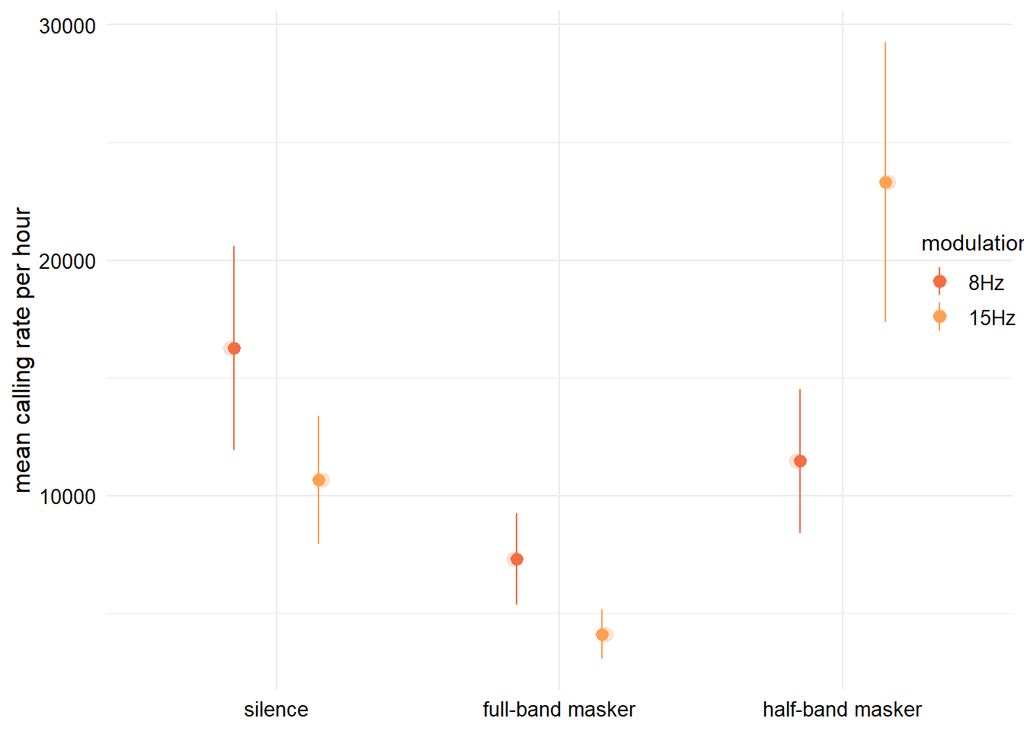

```r
preds <- do.call(rbind, lapply(all.models, '[[', 'predictions')) %>%
   mutate(across(is.numeric, round, 2)) %>%
   mutate(modulation = factor(str_split(row.names(.),"[.]",simplify = T)[,1],
          levels = sort(unique(data$modulation))),.before=1) %>%
   remove_rownames()

n_pred <- p.n_pred(preds) %>% recolor()

n_pred
```

```r
ggsave(file.path(figures_path,paste0(exp, '_fig1e.png') ), n_pred, width = 5, height = 4)
```

### Changes in call rate between modulation rate contexts

Now let’s see if there were changes in the overall rate of calling between different modulation rate contexts for the same playback condition.

```r
all.models2 <- lapply(sort(unique(n_calls_reg$condition)), function(x)
                      md <- run_negbinom_model(n_calls_reg %>% filter(condition==x),
                                               formula = "n ~  modulation",
                                               contformula = "~ modulation")  )
```

```
## [1] "~~~~~~~~~~~~~~  all rates  ~~~~~~~~~~~~~~"
## [1] "Model summary..."
##
## Call:
## MASS::glm.nb(formula = as.formula(formula), data = dat, init.theta = 0.8020944216,
##     link = log)
##
## Deviance Residuals:
##     Min       1Q   Median       3Q      Max
## -2.3470  -1.0491  -0.5147   0.3318   1.8880
##
## Coefficients:
##                Estimate Std. Error z value            Pr(>|z|)
## (Intercept)      9.6969     0.2497  38.837 <0.0000000000000002 ***
## modulation15Hz  -0.4212     0.3577  -1.178               0.239
## ---
## Signif. codes:  0 '***' 0.001 '**' 0.01 '*' 0.05 '.' 0.1 ' ' 1
##
## (Dispersion parameter for Negative Binomial(0.8021) family taken to be 1)
##
##     Null deviance: 47.643  on 38  degrees of freedom
## Residual deviance: 46.271  on 37  degrees of freedom
## AIC: 823
##
## Number of Fisher Scoring iterations: 1
##
##
##               Theta:  0.802
##           Std. Err.:  0.157
##
##  2 x log-likelihood:  -816.999
## [1] "Model dispersion..."
## [1] 1.024067
## [1] "Type II Deviance Table..."
## Analysis of Deviance Table (Type II tests)
##
## Response: n
##            LR Chisq Df Pr(>Chisq)
## modulation   1.3716  1     0.2415
## [1] "Incidence rates..."
```

[output cut: 120 more lines]

```
## modulation15Hz     2.034548    0.9507939     4.375076
## [1] "Estimated marginal mean contrasts..."
## $emmeans
##  modulation response   SE  df asymp.LCL asymp.UCL
##  8Hz           11466 3080 Inf      6773     19410
##  15Hz          23327 6428 Inf     13593     40034
##
## Confidence level used: 0.95
## Intervals are back-transformed from the log scale
##
## $contrasts
##  contrast   ratio    SE  df null z.ratio p.value
##  8Hz / 15Hz 0.492 0.189 Inf    1  -1.846  0.0649
##
## Tests are performed on the log scale
```

```r
names(all.models2) <- sort(unique(n_calls_reg$condition))
```

#### Anova

```r
# pull out anova tables
(anova2 <- do.call(rbind, lapply(all.models2, '[[', 'deviance')) %>%
   mutate(across(is.numeric, round, 2)))
```

```
##                  LR Chisq Df Pr(>Chisq)
## silence              1.37  1       0.24
## full-band masker     2.40  1       0.12
## half-band masker     3.36  1       0.07
```

#### Marginal mean contrasts

```
##         modulation   contrast  IRR   se asymp_lcl asymp_ucl z_ratio p_value
## 1          silence 8Hz / 15Hz 1.52 0.54      0.76      3.07    1.18    0.24
## 2 full-band masker 8Hz / 15Hz 1.78 0.65      0.86      3.65    1.56    0.12
## 3 half-band masker 8Hz / 15Hz 0.49 0.19      0.23      1.04   -1.85    0.06
```

#### Incidence Rate Ratios (IRR)

```r
# IRR
IRRs2 <- do.call(rbind, lapply(all.models2, '[[', 'IRR')) %>%
   mutate(across(is.numeric, round, 2)) %>%
   mutate(condition = str_split(row.names(.),"[.]",simplify = T)[,1], .before=1) %>%
   mutate(coef = str_remove(str_split(row.names(.),"[.]",simplify = T)[,2],"condition"), .after=1) %>%
   remove_rownames()
IRRs2
```

```
##          condition           coef Estimate    2.5 %   97.5 %
## 1          silence    (Intercept) 16266.65 10346.34 27712.87
## 2          silence modulation15Hz     0.66     0.32     1.34
## 3 full-band masker    (Intercept)  7309.35  4597.16 12648.54
## 4 full-band masker modulation15Hz     0.56     0.27     1.17
## 5 half-band masker    (Intercept) 11465.55  7066.19 20416.19
## 6 half-band masker modulation15Hz     2.03     0.95     4.38
```

### Anticipating the trough or the peak?

Use bootstrapped means from the whole data set, we now want to see whether average call onsets were “aimed” more at dodging AM peaks or more targeted at AM troughs.

```r
# timings by condition and modulation
more_timings <- mu_bs_time %>% group_by(modulation, condition) %>%
  summarise(median_peak = median(t_from_peak),
           iqr_peak = IQR(t_from_peak),
           mad_peak = mad(t_from_peak),
           median_trough = median(t_to_trough),
           mad_trough = mad(t_to_trough),
           iqr_trough = IQR(t_to_trough))

more_timings
```

```
## # A tibble: 6 × 8
## # Groups:   modulation [2]
##   modulation condition        median_peak iqr_peak mad_peak median_trough mad_trough iqr_trough
##   <fct>      <fct>                  <dbl>    <dbl>    <dbl>         <dbl>      <dbl>      <dbl>
## 1 8Hz        silence              -0.0295 0.0665   0.0326          0.092    0.0326     0.0665
## 2 8Hz        full-band masker      0.0519 0.000800 0.000593        0.0106   0.000593   0.000800
## 3 8Hz        half-band masker     -0.0112 0.00330  0.00252         0.0737   0.00252    0.00330
## 4 15Hz       silence               0.0072 0.0173   0.0125          0.0265   0.0125     0.0173
## 5 15Hz       full-band masker      0.0241 0.000800 0.000593        0.0096   0.000593   0.000800
## 6 15Hz       half-band masker     -0.022  0.00793  0.00578         0.0557   0.00578    0.00792
```

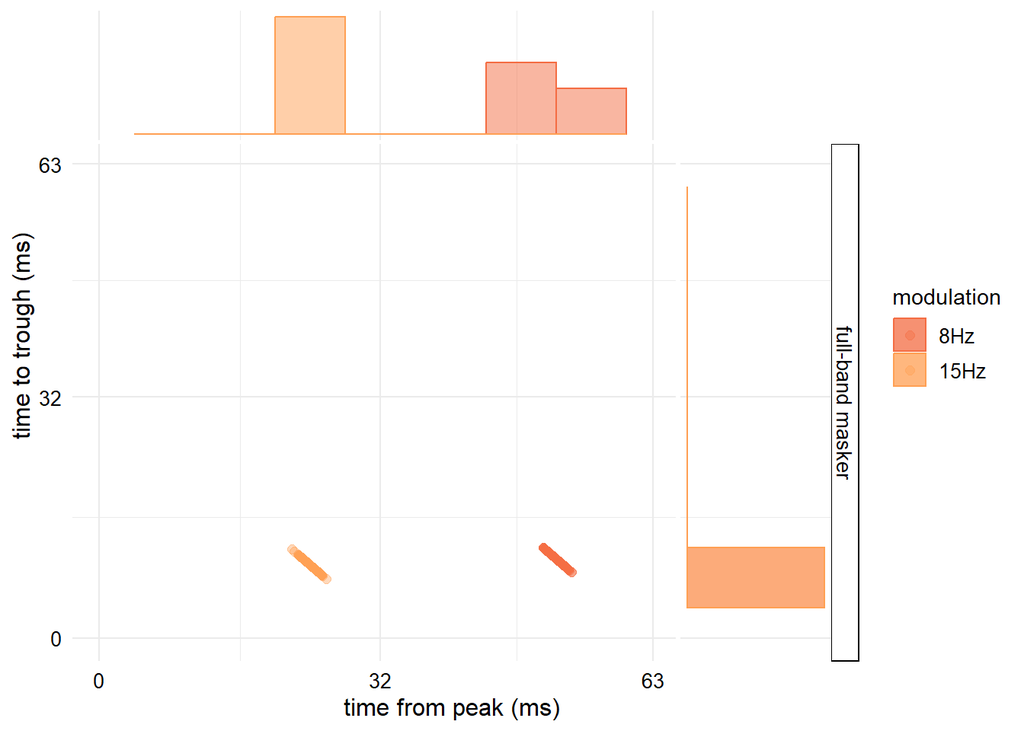

```r
pb <- p.peak_trough(mu_bs_time %>%
                      dplyr::filter(!condition=="silence", !condition=="half-band masker"), binwidth = 8) %>%
  recolor()

print(pb)
```

```r
ggsave(file.path(figures_path,paste0(exp, '_fig3a-alt1.png')), pb, width = 6, height = 4)
```

### Random Forest models

Run three versions of the random forest model:

1. A “full” model: $modulation ~ t_{peak} + t_{trough}$
2. A “peaks” model: $modulation ~ t_{peak}$
3. A “troughs” model: $modulation ~ t_{trough}$

```r
mu_rf <- mu_bs_time %>% dplyr::filter(!condition=="silence") %>%
  dplyr::select(t_to_trough, t_from_peak, modulation)

test_idx <- sample(1:nrow(mu_rf), size = floor(nrow(mu_rf)*0.60))

# split into 0.6:0.4 train/validation set
mu_bs_train <- mu_rf[test_idx,]
mu_bs_valid <- mu_rf[-test_idx,]

# shuffled
mu_bs_shuffled_pk <- mu_bs_train

rf_files <- c(file.path(models_path, paste0(exp,"_RF_full.RDS")),
              file.path(models_path, paste0(exp,"_RF_troughs_only.RDS")),
              file.path(models_path, paste0(exp,"_RF_peaks_only.RDS")))



if (all(file.exists(rf_files))) {
  rf_models <- lapply(rf_files, FUN = readr::read_rds)
  rf_classifier <- rf_models[[1]]
  rf_classifier_tr <- rf_models[[2]]
  rf_classifier_pk <- rf_models[[3]]
} else {

  # train
  # full model
  rf_classifier <- randomForest(modulation ~ ., data=mu_bs_train, ntree=500, mtry=2, importance=TRUE, proximity=TRUE)
  readr::write_rds(rf_classifier, file = rf_files[1])

  # only troughs
  rf_classifier_tr <- randomForest(modulation ~ t_to_trough, data=mu_bs_train, ntree=500, mtry=1, proximity=TRUE)
  readr::write_rds(rf_classifier_tr, file = rf_files[2])

  # only peaks
  rf_classifier_pk <- randomForest(modulation ~ t_from_peak, data=mu_bs_train, ntree=500, mtry=1, proximity=TRUE)
  readr::write_rds(rf_classifier_pk, file = rf_files[3])

  rf_models <- list(rf_classifier, rf_classifier_tr, rf_classifier_pk)


}
rf_classifier
```

```
##
## Call:
##  randomForest(formula = modulation ~ ., data = mu_bs_train, ntree = 500,      mtry = 2, importance = TRUE, proximity = TRUE)
##                Type of random forest: classification
##                      Number of trees: 500
## No. of variables tried at each split: 2
##
##         OOB estimate of  error rate: 0.04%
## Confusion matrix:
##       8Hz 15Hz  class.error
## 8Hz  1197    1 0.0008347245
## 15Hz    0 1202 0.0000000000
```

```r
rf_classifier_tr
```

```
##
## Call:
##  randomForest(formula = modulation ~ t_to_trough, data = mu_bs_train,      ntree = 500, mtry = 1, proximity = TRUE)
##                Type of random forest: classification
##                      Number of trees: 500
## No. of variables tried at each split: 1
##
##         OOB estimate of  error rate: 4.88%
## Confusion matrix:
##       8Hz 15Hz class.error
## 8Hz  1149   49  0.04090150
## 15Hz   68 1134  0.05657238
```

```r
rf_classifier_pk
```

```
##
## Call:
##  randomForest(formula = modulation ~ t_from_peak, data = mu_bs_train,      ntree = 500, mtry = 1, proximity = TRUE)
##                Type of random forest: classification
##                      Number of trees: 500
## No. of variables tried at each split: 1
##
##         OOB estimate of  error rate: 3.42%
## Confusion matrix:
##       8Hz 15Hz class.error
## 8Hz  1168   30  0.02504174
## 15Hz   52 1150  0.04326123
```

Predict modulation classes for the validation set for each of the models…

```r
predictions <- predict(rf_classifier,mu_bs_valid[,-3])
predictionstr <- predict(rf_classifier_tr,mu_bs_valid[,-3])
predictionspk <- predict(rf_classifier_pk,mu_bs_valid[,-3])

# predicted classes vs. observed classes
table(observed=mu_bs_valid[,3],predicted=predictions)
```

```
##         predicted
## observed 8Hz 15Hz
##     8Hz  802    0
##     15Hz   0  798
```

```r
print("Full model:")
```

```
## [1] "Full model:"
```

```r
# proportion misclassifications
mean(predictions != mu_bs_valid$modulation) * 100
```

```
## [1] 0
```

```r
# stats
(matfull <- caret::confusionMatrix(predictions, mu_bs_valid$modulation))
```

```
## Confusion Matrix and Statistics
##
##           Reference
## Prediction 8Hz 15Hz
##       8Hz  802    0
##       15Hz   0  798
##
##                Accuracy : 1
##                  95% CI : (0.9977, 1)
##     No Information Rate : 0.5012
##     P-Value [Acc > NIR] : < 0.00000000000000022
##
##                   Kappa : 1
##
##  Mcnemar's Test P-Value : NA
##
##             Sensitivity : 1.0000
##             Specificity : 1.0000
##          Pos Pred Value : 1.0000
##          Neg Pred Value : 1.0000
##              Prevalence : 0.5012
##          Detection Rate : 0.5012
##    Detection Prevalence : 0.5012
##       Balanced Accuracy : 1.0000
##
##        'Positive' Class : 8Hz
##
```

```r
print("Troughs model:")
```

```
## [1] "Troughs model:"
```

```r
# stats
(mattr <- caret::confusionMatrix(predictionstr, mu_bs_valid$modulation))
```

```
## Confusion Matrix and Statistics
##
##           Reference
## Prediction 8Hz 15Hz
##       8Hz  772   57
##       15Hz  30  741
##
##                Accuracy : 0.9456
##                  95% CI : (0.9334, 0.9562)
##     No Information Rate : 0.5012
##     P-Value [Acc > NIR] : < 0.00000000000000022
##
##                   Kappa : 0.8912
##
##  Mcnemar's Test P-Value : 0.005312
##
##             Sensitivity : 0.9626
##             Specificity : 0.9286
##          Pos Pred Value : 0.9312
##          Neg Pred Value : 0.9611
##              Prevalence : 0.5012
##          Detection Rate : 0.4825
##    Detection Prevalence : 0.5181
##       Balanced Accuracy : 0.9456
##
##        'Positive' Class : 8Hz
##
```

```r
print("Peaks model:")
```

```
## [1] "Peaks model:"
```

```r
# stats
(matpk <- caret::confusionMatrix(predictionspk, mu_bs_valid$modulation))
```

```
## Confusion Matrix and Statistics
##
##           Reference
## Prediction 8Hz 15Hz
##       8Hz  788   34
##       15Hz  14  764
##
##                Accuracy : 0.97
##                  95% CI : (0.9604, 0.9778)
##     No Information Rate : 0.5012
##     P-Value [Acc > NIR] : < 0.00000000000000022
##
##                   Kappa : 0.94
##
##  Mcnemar's Test P-Value : 0.006099
##
##             Sensitivity : 0.9825
##             Specificity : 0.9574
##          Pos Pred Value : 0.9586
##          Neg Pred Value : 0.9820
##              Prevalence : 0.5012
##          Detection Rate : 0.4925
##    Detection Prevalence : 0.5138
##       Balanced Accuracy : 0.9700
##
##        'Positive' Class : 8Hz
##
```

```r
validation <- list(matfull, mattr, matpk)
```

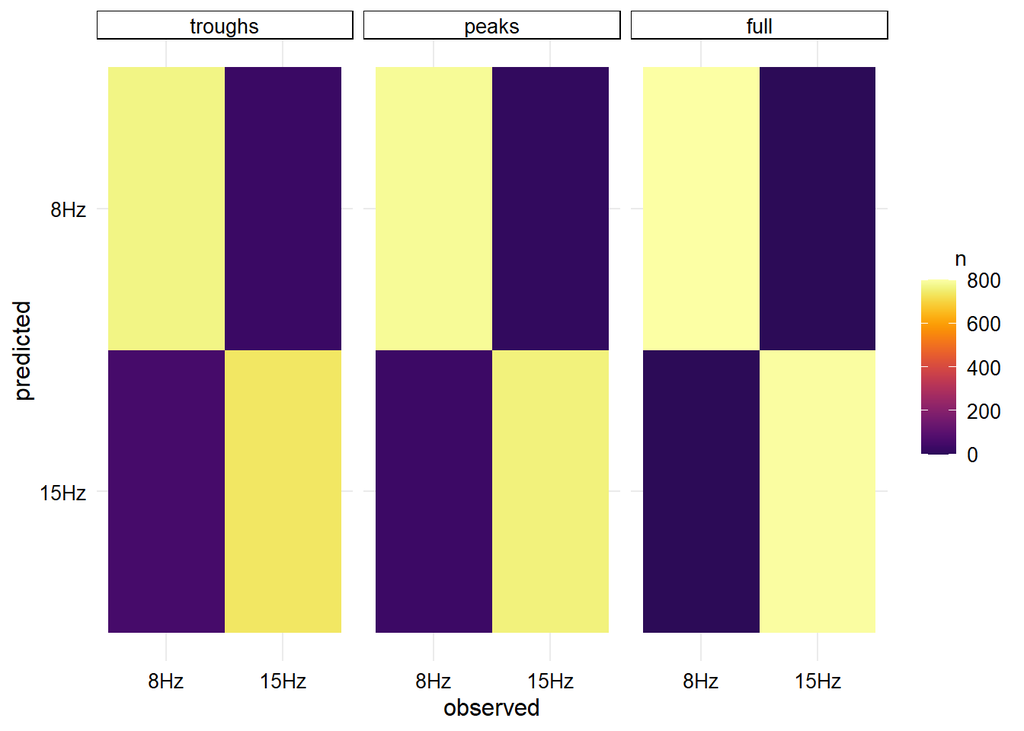

```r
# training matrices
# confmats <- lapply(rf_models,function(x) cormat_to_df(x$confusion[,-3])) %>%
#   setNames(c("full","troughs","peaks")) %>%
#   map_df(., ~as.data.frame(.x), .id="model") %>%
#   mutate(model = factor(model, levels = c("troughs","peaks","full")))

# validation matrices
confmats <- lapply(validation, function(x) cormat_to_df(x$table %>% as.data.frame()) ) %>%
  setNames(c("full", "troughs", "peaks")) %>%
  map_df(., ~as.data.frame(.x), .id="model") %>%
  mutate(model = factor(model, levels = c("troughs", "peaks", "full")))


confmat <- p.mat(confmats, ulim = max((mu_bs_valid%>%group_by(modulation)%>%summarise(n=n()))[,2])) +
  facet_grid(cols=vars(model))
  print(confmat)
```

```r
  ggsave(file.path(figures_path,paste0(exp, '_fig3b.png')),
         confmat, width = h, height = w2)
```

#### Shuffled Forests

Now, let’s see what happens if we shuffle the modulation class labelled for one or the other measure in our full model. The drop in performance, respectively, should give us some insight into which variable is doing more of the legwork.

```r
# shuffled
mu_bs_shuffled_pk <- mu_bs_train
mu_bs_shuffled_pk$t_from_peak <- mu_bs_shuffled_pk$t_from_peak[sample(1:nrow(mu_bs_shuffled_pk))]

mu_bs_shuffled_tr <- mu_bs_train
mu_bs_shuffled_tr$t_to_trough <- mu_bs_shuffled_tr$t_to_trough[sample(1:nrow(mu_bs_shuffled_tr))]

# train
# full model
shPeak_rf_classifier <- randomForest(modulation ~ ., data=mu_bs_shuffled_pk, ntree=500, mtry=2, importance=TRUE, proximity=TRUE)
shPeak_rf_classifier
```

```
##
## Call:
##  randomForest(formula = modulation ~ ., data = mu_bs_shuffled_pk,      ntree = 500, mtry = 2, importance = TRUE, proximity = TRUE)
##                Type of random forest: classification
##                      Number of trees: 500
## No. of variables tried at each split: 2
##
##         OOB estimate of  error rate: 7.54%
## Confusion matrix:
##       8Hz 15Hz class.error
## 8Hz  1108   90  0.07512521
## 15Hz   91 1111  0.07570715
```

```r
shTrough_rf_classifier <- randomForest(modulation ~ ., data=mu_bs_shuffled_tr, ntree=500, mtry=2, importance=TRUE, proximity=TRUE)
shTrough_rf_classifier
```

```
##
## Call:
##  randomForest(formula = modulation ~ ., data = mu_bs_shuffled_tr,      ntree = 500, mtry = 2, importance = TRUE, proximity = TRUE)
##                Type of random forest: classification
##                      Number of trees: 500
## No. of variables tried at each split: 2
##
##         OOB estimate of  error rate: 4.58%
## Confusion matrix:
##       8Hz 15Hz class.error
## 8Hz  1157   41  0.03422371
## 15Hz   69 1133  0.05740433
```

Let’s get predictions as before…

```r
predictionstr_sh <- predict(shTrough_rf_classifier,mu_bs_valid[,-3])
predictionspk_sh <- predict(shPeak_rf_classifier,mu_bs_valid[,-3])

print("Shuffled troughs:")
```

```
## [1] "Shuffled troughs:"
```

```r
# stats
shtr <- caret::confusionMatrix(predictionstr_sh , mu_bs_valid$modulation)
shtr
```

```
## Confusion Matrix and Statistics
##
##           Reference
## Prediction 8Hz 15Hz
##       8Hz  785   48
##       15Hz  17  750
##
##                Accuracy : 0.9594
##                  95% CI : (0.9485, 0.9685)
##     No Information Rate : 0.5012
##     P-Value [Acc > NIR] : < 0.00000000000000022
##
##                   Kappa : 0.9187
##
##  Mcnemar's Test P-Value : 0.0001984
##
##             Sensitivity : 0.9788
##             Specificity : 0.9398
##          Pos Pred Value : 0.9424
##          Neg Pred Value : 0.9778
##              Prevalence : 0.5012
##          Detection Rate : 0.4906
##    Detection Prevalence : 0.5206
##       Balanced Accuracy : 0.9593
##
##        'Positive' Class : 8Hz
##
```

```r
print("Shuffled peaks:")
```

```
## [1] "Shuffled peaks:"
```

```r
# stats
shpk <- caret::confusionMatrix(predictionspk_sh , mu_bs_valid$modulation)
shpk
```

```
## Confusion Matrix and Statistics
##
##           Reference
## Prediction 8Hz 15Hz
##       8Hz  779   88
##       15Hz  23  710
##
##                Accuracy : 0.9306
##                  95% CI : (0.9171, 0.9426)
##     No Information Rate : 0.5012
##     P-Value [Acc > NIR] : < 0.00000000000000022
##
##                   Kappa : 0.8612
##
##  Mcnemar's Test P-Value : 0.000000001243
##
##             Sensitivity : 0.9713
##             Specificity : 0.8897
##          Pos Pred Value : 0.8985
##          Neg Pred Value : 0.9686
##              Prevalence : 0.5012
##          Detection Rate : 0.4869
##    Detection Prevalence : 0.5419
##       Balanced Accuracy : 0.9305
##
##        'Positive' Class : 8Hz
##
```

```r
validation_sh <- list(shtr, shpk)
```

How did variable importance metrics compare between the full (unshuffled) version and the two shuffled versions?

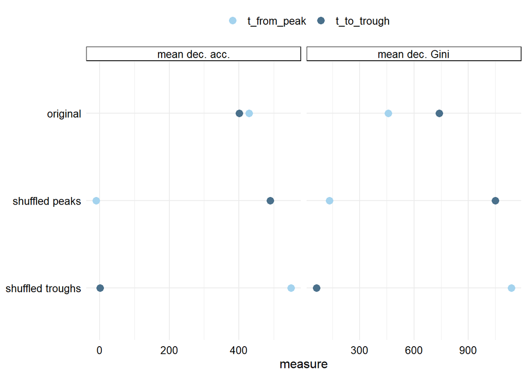

```r
importance_sh <- importance(shTrough_rf_classifier)  %>% importance_to_df()
importance_shpk <- importance(shPeak_rf_classifier) %>% importance_to_df()
compare <- rbind(importance_shpk %>% mutate(shuffle = "shuffled peaks"),
                  importance_sh %>% mutate(shuffle = "shuffled troughs"),
                  importance %>% mutate(shuffle = "original"))

p.imp.sh <- p.importance_shuffled(compare)
p.imp.sh
```

```r
ggsave(file.path(figures_path,paste0(exp, '_fig3c.png')),p.imp.sh, width = 4, height = 4)
```

Finally, here’s how our shuffled modelled fared at classifying modulation rate classes…

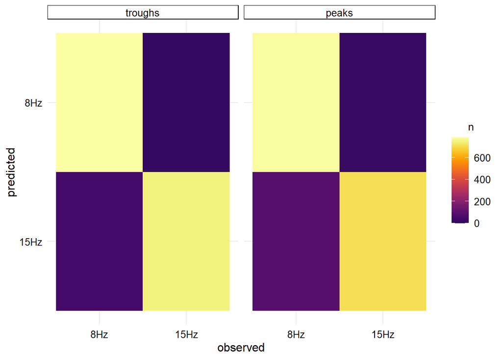

```r
# validation matrices
confmats_sh <- lapply(validation_sh, function(x) cormat_to_df(x$table %>% as.data.frame()) ) %>%
  setNames(c("troughs", "peaks")) %>%
  map_df(., ~as.data.frame(.x), .id="model") %>%
  mutate(model = factor(model, levels = c("troughs", "peaks", "full")))


confmat_sh <- p.mat(confmats_sh, ulim = max(confmats_sh$n)) +
  facet_grid(cols=vars(model))

  print(confmat_sh)
```

```r
  ggsave(file.path(figures_path,paste0(exp, '_figs6.png')),
         confmat_sh, width = h, height = w3)
```

#### Quantify overlapping calls

```r
overlap_calls <- data[which(data$onset_interval<data$duration),]%>%
  mutate(overlap = duration-onset_interval)

cat("Of a total of", nrow(data), "calls,", nrow(overlap_calls),
    "(", round(nrow(overlap_calls)/nrow(data)*100,2), "%) overlapped in time.")
```

```
## Of a total of 1425067 calls, 42618 ( 2.99 %) overlapped in time.
```

```r
n_overlap <- overlap_calls %>% group_by(modulation, condition) %>% summarise(n = n())

(n_overlap_conttable <- addmargins(table(overlap_calls$modulation,overlap_calls$condition), c(1,2)))
```

```
##
##        silence full-band masker half-band masker   Sum
##   8Hz    13534             4804             8734 27072
##   15Hz    4111              823            10612 15546
##   Sum    17645             5627            19346 42618
```

#### Modelling call overlap incidence

Let’s run the overlap data through a negative binomial…

Deviance tables…

```r
(ovlp.anova <- do.call(rbind, lapply(ovlp.models, '[[', 'deviance')) %>%
   mutate(across(is.numeric, round, 2)))
```

```
##            LR Chisq Df Pr(>Chisq)
## condition      2.52  2       0.28
## condition1    24.89  2       0.00
```

And contrasts…

```r
(contrasts <- do.call(rbind, lapply(ovlp.models, '[[', 'contrasts')) %>%
   mutate(across(is.numeric, round, 2)) %>%
   mutate(modulation = factor(rep(unique(n_overlap$modulation),each=length(unique(n_overlap$condition)))),.before=1) %>%
   remove_rownames() %>%
   dplyr::select(-c("df", "null")) %>%
   dplyr::rename(IRR = ratio))
```

```
##   modulation                       masking_condition  IRR   se asymp_lcl asymp_ucl z_ratio p_value
## 1        8Hz            silence / (full-band masker) 2.40 1.28      0.66      8.65    1.63    0.31
## 2        8Hz            silence / (half-band masker) 1.40 0.74      0.39      4.94    0.63    1.00
## 3        8Hz (full-band masker) / (half-band masker) 0.58 0.32      0.16      2.17   -0.98    0.98
## 4       15Hz            silence / (full-band masker) 4.73 2.19      1.56     14.36    3.35    0.00
## 5       15Hz            silence / (half-band masker) 0.37 0.17      0.12      1.11   -2.17    0.09
## 6       15Hz (full-band masker) / (half-band masker) 0.08 0.04      0.03      0.24   -5.44    0.00
```

And finally, predict values…

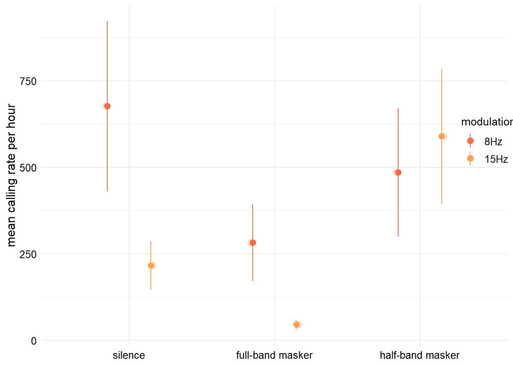

```r
ovlp_preds <- do.call(rbind, lapply(ovlp.models, '[[', 'predictions')) %>%
   mutate(across(is.numeric, round, 2)) %>%
   mutate(modulation = factor(rep(unique(n_overlap$modulation),each=length(unique(n_overlap$condition))))) %>%
   remove_rownames()

ovlp_pred <- p.n_pred(ovlp_preds) %>% recolor()

ovlp_pred
```

```r
ggsave(file.path(figures_path,paste0(exp, '_figs7b.png') ), ovlp_pred, width = 5, height = 4)
```

Finally, we can calculate circular stats for overlapping calls, and visualize the angular vectors representing those distributions for each condition:

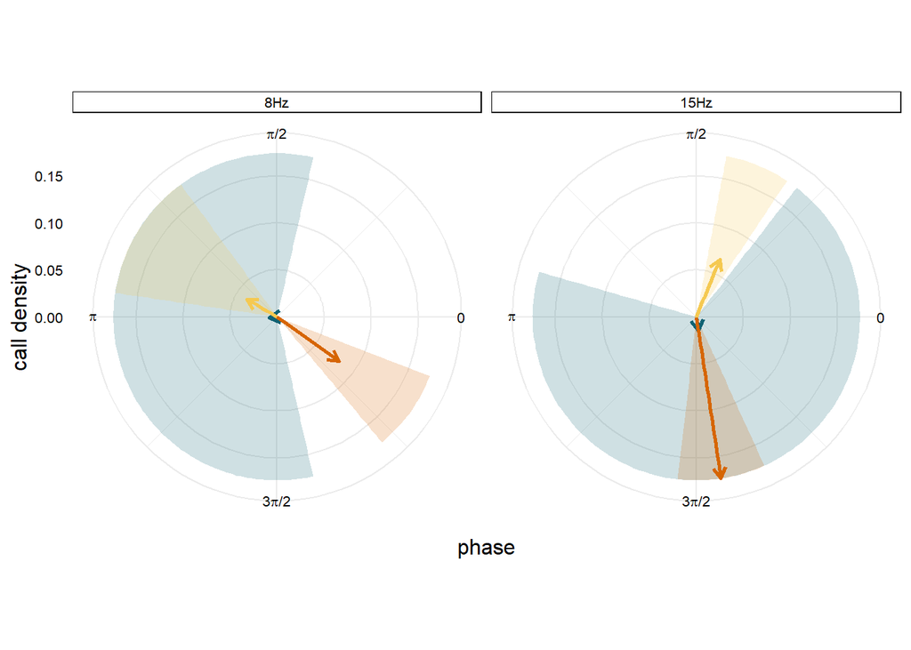

```r
overlap_circsummary <- overlap_calls %>%
    group_by(modulation, condition) %>%
    summarize(n = n(),
           theta_bar = mean.circular(start_phase_circ, na.rm = T),
           r_bar = rho.circular(start_phase_circ, na.rm = T),
           vm = var.circular(start_phase_circ),
           rt = rayleigh.test(start_phase_circ, mu=circular(0))$statistic,
           p = rayleigh.test(start_phase_circ, mu=circular(0))$p.value,
           bs_mu_ci_l = mle.vonmises.bootstrap.ci(start_phase_circ, alpha=.05)$mu.ci[1],
           bs_mu_ci_h = mle.vonmises.bootstrap.ci(start_phase_circ, alpha=.05)$mu.ci[2],) %>%
    mutate(p_adjust = p.adjust(p, method ="bonferroni"), .after = "p") %>%
    mutate(across(where(is.numeric), round, 3))

overlap_circsummary %>%
  kbl(escape = FALSE,
      booktabs = TRUE,
      format = "html",
      caption = "Circular statistics for overlapping calls") %>%
  kable_styling() %>%
  cat(., file = file.path(tables_path,paste0(exp, "_circ_stats_overlap.html")))

p.ang <- p.angular_vectors(overlap_circsummary %>% confint_wrap())

p.ang
```

```r
 ggsave(file.path(figures_path,paste0(exp, '_figs7a.png') ), p.ang, width = w, height = 4)
```

```r
po <- p.circ_density(dat=overlap_calls, circ_dat=overlap_circsummary %>% confint_wrap(), bins = 30) %>% recolor(which = "f")
  print(po)
```

[figure not shown]

```r
  ggsave(file.path(figures_path,paste0(exp, '_figs7a-alt2.png') ), po, width = w, height = 5)
```

### Investigate the onset of this adaptation ability

To determine how many cycles of continuous stimulation are needed for the bats’s timing adaptation to stabilize, estimate mean and concentration parameters for successively larger cycle windows:

```r
max_n <- data_init %>% group_by(modulation, condition) %>% summarise(n = max(start_cycle)) %>%
  ungroup() %>% summarise(min = min(n))

by_cycle_summary <- data.frame()
for (c in seq(0, max_n$min, 10)) {
#for (c in 2:length(seq(0, max_n, 10))) {
  #s <- seq(0, 1000, 10)
  dat_summary <- data_init %>%
    dplyr::filter(start_cycle <= c) %>%
    #dplyr::filter(start_cycle > s[c-1] & start_cycle <= s[c]) %>% # non-cumulative
    group_by(modulation, condition) %>% # pool over groups
    summarize(n = c,
           theta_bar = mean.circular(start_phase_circ, na.rm = T) %>% as.numeric(),
           r_bar = rho.circular(start_phase_circ, na.rm = T))
  by_cycle_summary <- rbind(by_cycle_summary, dat_summary)
}
```

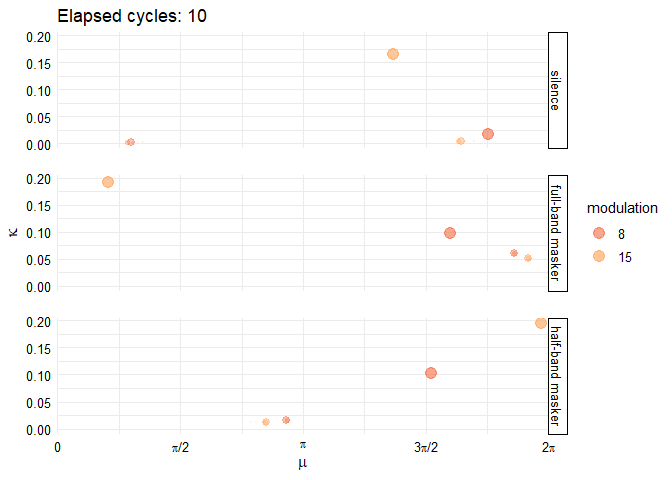

### References

Some references for circular stats can be found from the [NCSS website](https://ncss-wpengine.netdna-ssl.com/wp-content/themes/ncss/pdf/Procedures/NCSS/Circular_Data_Analysis.pdf), as well as the documentation for the [Matlab](https://www.jstatsoft.org/article/view/v031i10) library for circular stats, and articles written on [Bayesian modelling of circular data](https://journals.sagepub.com/doi/pdf/10.1177/1471082X10000301).

There is also the textbook, [*Statistical analysis of circular data*](https://books.google.de/books?id=wGPj3EoFdJwC&printsec=frontcover#v=onepage&q&f=false), as well as: - Batschelet, E. (1981). *Circular Statistics in Biology.* Academic Press: London. - Jammalamadaka, S.R. & Sengupta, A. (2001). *Topics in Circular Statistics.* World Scientific, River Edge, N.J.